# Written Report - Analyzing Digital Footprint - Group 6

Adam Chan, Khanh Chu, Shiyun Chen, Yuanling Zhu, Jing Jing He

2024-06-21 at 16:42:49

# 1 Introduction

## 1.1 Research question

What are the key dynamics and factors of Kiva projects that influence fundraising processes, and how can they be used to develop a model to predict future project successes?

## 1.2 Importance of Answering the RBQ

Answering this RBQ is crucial for several reasons and benefits multiple stakeholders, including borrowers, Kiva as a platform, and lenders.

**For Borrowers**: Knowing which features attract funding can help borrowers present their projects better. They are able to set realistic expectations about their projects’ size and goals, which improves their chances of success. For instance, if detailed project descriptions and high-quality images are known to attract more funds, borrowers can focus on these aspects.

**For Kiva**: Data-driven insights enable Kiva to offer personalized guidance to borrowers to enhance their chances of success, thus improving the platform’s overall impact. Additionally, Kiva could better tailor their business strategy. They might prioritize the projects that are likely to successfully meet their fundraising goals, while supporting projects that are unlikely to be funded by showcasing them on the front page to increase attraction and engagement.

**For Lenders**: Predictive tools assist lenders in deciding which projects are more likely to fulfill their funding goals, thereby enhancing investment decisions. For example, if certain projects are unlikely to meet their goals, lenders might consider supporting them more carefully or avoid potential setbacks.

## 1.3 Prior Research and Practices

Prior research and business practices have consistently highlighted several key factors that significantly influence the success of crowdfunding and microfinance projects. These factors include project characteristics such as sector, amount requested, description text, duration of the fundraising campaign, use of multimedia (photos, videos), loan distribution, risk rating, profitability, and loan funding type (Belleflamme et al., 2014; Paruthi et al., 2016).

In microfinance, borrower credibility, economic conditions, and the social impact of the project are crucial. Dorfleitner, Oswald, and Zhang (2021) found that projects with higher social impact scores attract more funding. Agier and Szafarz (2013) revealed a “glass ceiling” effect in loan sizes for female borrowers, underscoring the importance of demographic factors such as gender, age, location, education level, and economic background. Cultural and emotional factors also play a significant role. Park et al. (2020) demonstrated that culturally valued facial expressions enhance loan success, while Pengnate and Riggins (2020) found that the emotional tone of project descriptions significantly impacts funding outcomes.

Although Kiva has conducted analyses on general success rates, there is potential to fully leverage predictive analytics for forecasting project outcomes by investigating the most updated lender preferences and the dynamic interactions between borrowers and lenders. Existing analyses may not deeply explore these areas, presenting an opportunity for deeper insights and improved predictive models (Bouncken et al., 2015; Cumming et al., 2019).

In summary, integrating these insights from prior research provides a robust foundation for understanding the key features that contribute to the success of Kiva projects. This understanding can help develop more effective strategies for enhancing project presentations, supporting successful fundraising, and better engaging lenders.

# 2 Data

## 2.1 Data Acquisition

For this study, we initially collected a comprehensive dataset through [Kiva API](https://api.kivaws.org/graphql) on May 15th, which included 6493 observations and 10 variables. These observations encompass a variety of attributes related to the projects, borrowers, and their engagement metrics. The 10 variables are described below.

```r
# Source: https://api.kivaws.org/graphql
data.frame(
  `Variable` = c(
    "loan_id",
    "sentiment",
    "gender",
    "lenderRepaymentTerm",
    "loanAmount",
    "daysSinceFundraising",
    "fundedAmount",
    "country",
    "researchScore",
    "sector"
  ),
  `Description` = c(
    "Shows the loan ID.",
    "Shows sentiment of description text, showing the degree of negativity or positivity in a text.",
    "Shows the gender of the primary borrower or majority gender if group.",
    "The number of months it will take the borrower to repay the loan.",
    "The amount of this loan, as shown to lenders.",
    "Number of days that have been passed since the fundraising date. Since the data acquisition date is May 15th 2024, it shows the difference between the start of the campagin and May 15th.",
    "Shows the amount funded.",
    "The country of lender.",
    "Refers to an internal score given by Kiva internally to determine alignment with social impact or effectiveness in achieving positive social outcomes.",
    "A sector is a broad category for a loan, e.g. Agriculture, Arts, Clothing. Sectors are subdivided further by activities."

  )) %>%
  reactable::reactable(
    rownames = FALSE,
    defaultPageSize = 16,
    showPageSizeOptions = F,
    searchable = T,
    compact = T,
    paginateSubRows = T,
    highlight = T,
    bordered = T,
    wrap = T,
    resizable = T
  )
```

| Variable | Description |
| --- | --- |
| loan_id | Shows the loan ID. |
| sentiment | Shows sentiment of description text, showing the degree of negativity or positivity in a text. |
| gender | Shows the gender of the primary borrower or majority gender if group. |
| lenderRepaymentTerm | The number of months it will take the borrower to repay the loan. |
| loanAmount | The amount of this loan, as shown to lenders. |
| daysSinceFundraising | Number of days that have been passed since the fundraising date. Since the data acquisition date is May 15th 2024, it shows the difference between the start of the campagin and May 15th. |
| fundedAmount | Shows the amount funded. |
| country | The country of lender. |
| researchScore | Refers to an internal score given by Kiva internally to determine alignment with social impact or effectiveness in achieving positive social outcomes. |
| sector | A sector is a broad category for a loan, e.g. Agriculture, Arts, Clothing. Sectors are subdivided further by activities. |

### 2.1.1 Data Request Kiva API

To request data via the [Kiva API](https://api.kivaws.org/graphql), we first aimed to create a query to filter for the loans’ ID that met our criteria, i.e. maximizing the number of observations subject to the above mentioned variables (see details below).

**Query Kiva API to get Unique IDs**

```r
{
  lend {
    loans (sortBy: newest) {
      totalCount
      values {
        id
      }
    }
  }
}
```

This is performed in the `collect_data_uniqueID.R` file.

As the request was placed we found that only a maximum of 100 observations could be obtained, which is not equal to the `total count` of such filter. Therefore, to override this limitation, we used a loop in combination with the `limit` and `offset` arguments in the query to request the total number of unique IDs (see `collect_data_uniqueID.R` file). These are saved in a vector, and were used to find the remaining variable values via the query that is depicted below (see `collect_data_API.R` file).

**Query Kiva API to get Values based on Unique IDs**

Note: The query below with the variables that are requested are not the same as the ones mentioned before. Here our goal was to maximize information, which then is further processed in the next section.

```r
{
  lend {
    loan(id:{loan_id}) { # loan_id is variable used to loop through
      id                  # the unique IDs
      description
      disbursalDate
      fundraisingDate
      raisedDate
      plannedExpirationDate
      status
      gender
      lenderRepaymentTerm
      use
      geocode {
        city
        state
        postalCode
        latitude
        longitude
        country {
          name
          isoCode
          region
          ppp
          numLoansFundraising
          fundsLentInCountry
        }
      }
      name
      video {
        thumbnailImageId
        youtubeId
      }
      loanAmount
      repaymentInterval
      delinquent
      hasCurrencyExchangeLossLenders
      loanFundraisingInfo {
        fundedAmount
        reservedAmount
        isExpiringSoon
      }
      researchScore
      image {
        url(presetSize:small)
      }
      activity {
        name
      }
      sector {
        name
      }
    }
  }
}
```

This is performed in the `collect_data_API.R` file.

These results are saved in JSON format, which need to be tidied in order to be usable for further analysis.

### 2.1.2 Data Processing

To transform our data into [tidy format](https://r4ds.had.co.nz/tidy-data.html), we use the packages `httr2` and `tidyverse`. Here, the most important aspect is to extract the elements in the lists using the `map()` function the `purrr` package from `tidyverse`. Some elements are in nested lists, which are extracted via seperate functions (see `f_aux_functions.R` file). The resulting data are saved in a data frame, and, if needed, the classes of variables are changed to accommodate them (see `process_data.R` file). Furthermore, features are engineered to accommodate analysis and lastly, the 10 relevant variables (see section above) are selected.

### 2.1.3 Variable Exploration: Descriptive Analysis

#### 2.1.3.1 Numeric Variables

The numeric variables of interest collected are detailed below:

```r
df_loans %>%
  select(
    "sentiment",
    "lenderRepaymentTerm",
    "loanAmount",
    "daysSinceFundraising",
    "fundedAmount",
    "researchScore"
  ) %>%
  as.data.frame() %>%
  stargazer(type = "html")
```

| Statistic | N | Mean | St. Dev. | Min | Max |
| --- | --- | --- | --- | --- | --- |
| sentiment | 6,493 | 7.280 | 4.548 | 0 | 33 |
| lenderRepaymentTerm | 6,493 | 15.096 | 6.663 | 5 | 122 |
| loanAmount | 6,493 | 1,427.518 | 4,204.432 | 100 | 300,000 |
| daysSinceFundraising | 6,493 | 14.505 | 9.077 | 0 | 42 |
| fundedAmount | 6,493 | 0.167 | 0.189 | 0.000 | 1.000 |
| researchScore | 6,458 | 6.926 | 4.213 | 0.000 | 37.500 |

Note that researchScore here refers to an internal score given by Kiva internally to determine alignment with social impact or effectiveness in achieving positive social outcomes.

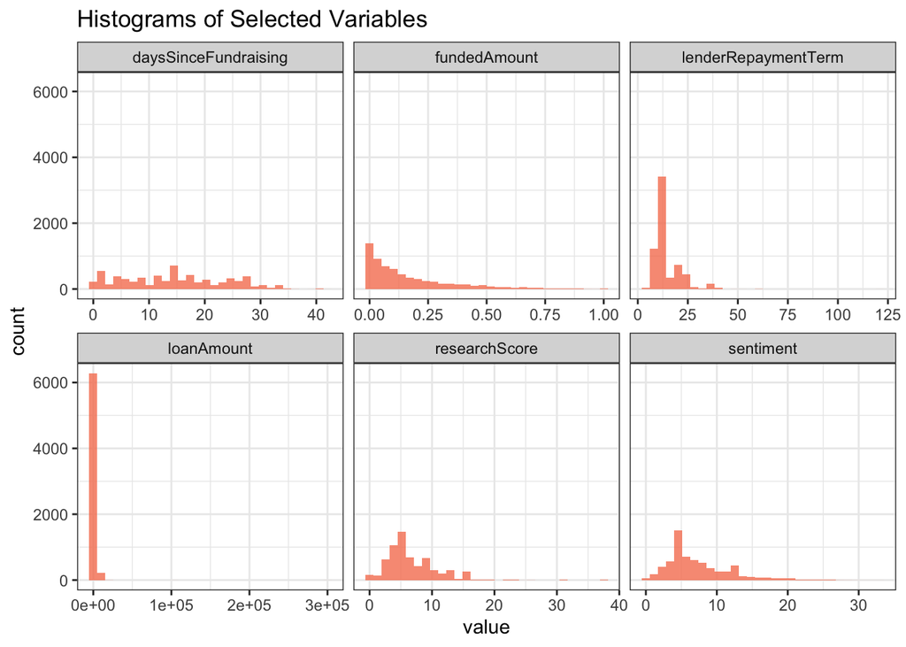

```r
df_loans_selected <- df_loans %>%
  select(
    sentiment,
    lenderRepaymentTerm,
    loanAmount,
    daysSinceFundraising,
    fundedAmount,
    researchScore
  ) %>%
  as.data.frame()

# Reshape the data to long format
df_long <- df_loans_selected %>%
  pivot_longer(cols = everything(), names_to = "variable", values_to = "value")

# Create the plot
ggplot(df_long, aes(x = value)) +
  geom_histogram(fill = "#f68060", alpha = .8, bins = 30) +
  labs(title = "Histograms of Selected Variables") +
  theme_minimal() +
  theme_bw() +
  facet_wrap(~ variable, nrow = 2, ncol = 3, scales = "free_x")
```

#### 2.1.3.2 Country

The top 6 frequent country distribution table is as follows.

```r
df_loans %>%
  select(country) %>%
  count(country) %>%
  arrange(desc(n)) %>%
  reactable::reactable(
    rownames = FALSE,
    defaultPageSize = 6,
    showPageSizeOptions = F,
    searchable = T,
    compact = T,
    paginateSubRows = T,
    highlight = T,
    bordered = T,
    wrap = T,
    resizable = T
  )
```

| country | n |
| --- | --- |
| Philippines | 693 |
| El Salvador | 610 |
| Kenya | 551 |
| Ecuador | 421 |
| Colombia | 377 |
| Tajikistan | 361 |
| Uganda | 343 |
| Nicaragua | 321 |
| Senegal | 265 |
| Honduras | 263 |

[output cut: 44 more lines]

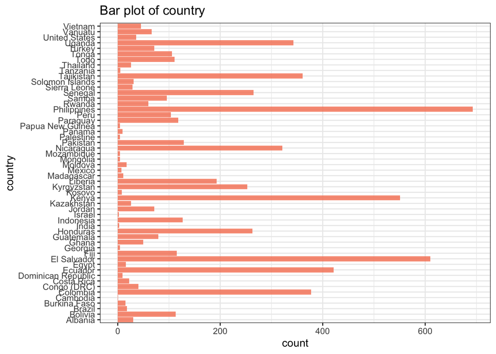

```r
ggplot(df_loans, aes(x = country)) +
    geom_bar(fill = "#f68060", alpha = .8, bins = 30) +
    labs(title = paste("Bar plot of country")) +
    theme_bw() +
    coord_flip()
```

#### 2.1.3.3 Sector

The top 6 frequent sector distribution tables is as follows.

```r
df_loans %>%
  select(sector) %>%
  count(sector) %>%
  arrange(desc(n)) %>%
  reactable::reactable(
    rownames = FALSE,
    defaultPageSize = 6,
    showPageSizeOptions = F,
    searchable = T,
    compact = T,
    paginateSubRows = T,
    highlight = T,
    bordered = T,
    wrap = T,
    resizable = T
  )
```

| sector | n |
| --- | --- |
| Agriculture | 1910 |
| Food | 1687 |
| Retail | 1247 |
| Services | 474 |
| Clothing | 377 |
| Housing | 206 |
| Arts | 202 |
| Transportation | 83 |
| Health | 82 |
| Construction | 81 |

[output cut: 5 more lines]

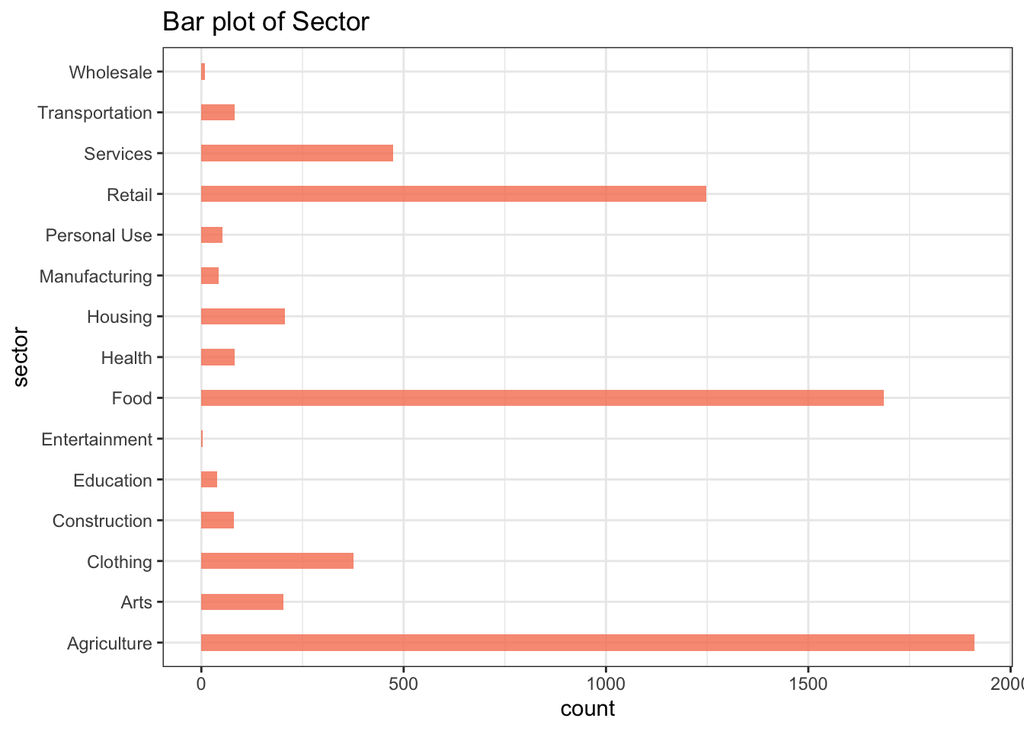

```r
ggplot(df_loans, aes(x = sector)) +
  geom_bar(fill = "#f68060",
           alpha = .8,
           width = .4) +
  labs(title = paste("Bar plot of Sector")) +
  theme_minimal() +
  theme_bw() +
  coord_flip()
```

#### 2.1.3.4 gender

The gender distribution table is as follows.

```r
df_loans %>%
  select(gender) %>%
  count(gender) %>%
  arrange(desc(n)) %>%
  reactable::reactable(
    rownames = FALSE,
    defaultPageSize = 6,
    showPageSizeOptions = F,
    searchable = T,
    compact = T,
    paginateSubRows = T,
    highlight = T,
    bordered = T,
    wrap = T,
    resizable = T
  )
```

| gender | n |
| --- | --- |
| female | 4909 |
| male | 1584 |

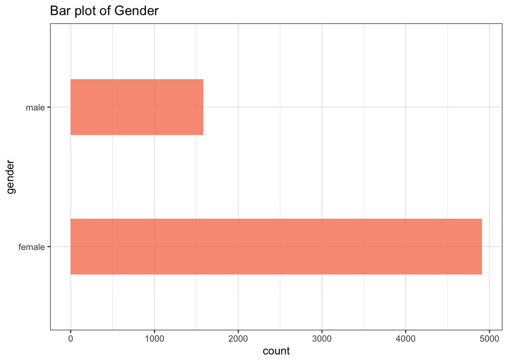

```r
ggplot(df_loans, aes(x = gender)) +
  labs(title = paste("Bar plot of Gender")) +
  geom_bar(fill = "#f68060",
           alpha = .8,
           width = .4) +
  theme_minimal() +
  theme_bw() +
  coord_flip()
```

## 2.2 Cluster Analysis

Given the limitations of our dataset, which only included a small number of completed projects, it was impractical to construct predictive models. As a result, we shifted our approach to cluster analysis to identify patterns and relationships within the data. This method allows us to gain insights into the dynamics and key factors influencing Kiva’s fundraising process.

### 2.2.1 Analysis

```r
clusterAnalysis_file_name <- here::here("sections", "section_2", "section_2_clusterAnalysis_clustering.R")
clusterAnalysis_start_line <- 1
clusterAnalysis_end_line <- 72


knitr::read_chunk(
  path = clusterAnalysis_file_name,
  labels = "clusterAnalysis-params",
  from = clusterAnalysis_start_line,
  to = clusterAnalysis_end_line
)

file_in_repo <- stringr::str_sub(
  clusterAnalysis_file_name,
  start = stringr::str_locate(clusterAnalysis_file_name, "/section_2_clusterAnalysis_clustering.R")[1, "start"]
)
```

```r
library(tidymodels)
library(tidyverse)
library(NbClust)
library(GGally)
library(ggdendro)
library(purrr)


#Load the processed data
load(here::here("data_retrieval", "process_data.RData"))


#Set seed for reproducability
set.seed(2503)


#Recipe
data_processing <-
  recipe(~., data = df_loans) |>
  step_rm(loan_id) |>
  step_impute_knn(all_predictors(), neighbors = 5) |>
  step_range(sentiment, lenderRepaymentTerm, daysSinceFundraising, loanAmount, researchScore) |>
  step_dummy(all_nominal(), -all_outcomes())


#Function to activate recipe
cook_it <- function(recipe) {
  baked <- recipe |> prep() |> bake(new_data = NULL)
  return(baked)
}


#Test for best k
multiple_k_means <- function(recipe, max_k) {
  baked <- cook_it(recipe)

  tibble(k = seq_len(max_k)) |>
    mutate(
      kmc = map(k, ~ kmeans(baked,
                            centers = .x,
                            nstart = 1000
      )),
      kmc_glance = map(kmc, glance),
      kmc_tidy = map(kmc, tidy),
      kmc_augment = map(kmc, augment, baked)
    )
}


#Graph
km_fit <-
  data_processing |>
  multiple_k_means(20) |>
  unnest(cols = c(kmc_glance)) |>
  select(-starts_with("kmc")) |>
  ggplot() +
  aes(x = k, y = tot.withinss / totss) +
  geom_point() +
  geom_line() +
  theme_bw() +
  scale_y_continuous(labels = scales::percent)


#Chosen k is 5. Run the code and categorize observations into clusters
set.seed(2503)
final <- kmeans(cook_it(data_processing), centers = 5, nstart = 1000)
final <- final |>
  augment(df_loans)
final <- final |>
  rename(cluster = .cluster)

km_fit
```

[output not shown]

From here, we will extract summary statistics from these clusters. The numerical means of clusters will be presented in a compact table, while the value count of categorical values is presented cluster-by-cluster. We will add our observations about the clusters along with the categorical count.

```r
load(here::here("sections", "section_2", "clusters.Rdata"))

# Function to summarize numerical data and count observations in a cluster
summarize_cluster_numerical <- function(cluster_number, data) {
  numerical_summary <- data %>%
    filter(cluster == cluster_number) %>%
    select(where(is.numeric), -loan_id) %>%
    summarise_all(list(mean = ~ mean(., na.rm = TRUE)))

  count_summary <- data %>%
    filter(cluster == cluster_number) %>%
    summarise(count = n()) %>%
    rename(number_of_observations = count)

  summary <- bind_cols(numerical_summary, count_summary) %>%
    mutate(cluster = cluster_number)

  return(summary)
}

# Generate summaries for clusters 1 to 5
numeric_stats <- map_dfr(1:5, ~ summarize_cluster_numerical(.x, final)) %>%
  pivot_longer(cols = -cluster, names_to = "variable", values_to = "value") %>%
  pivot_wider(names_from = cluster, values_from = value, names_prefix = "cluster_")

print(numeric_stats)
```

```
## # A tibble: 7 × 6
##   variable                  cluster_1 cluster_2 cluster_3 cluster_4 cluster_5
##   <chr>                         <dbl>     <dbl>     <dbl>     <dbl>     <dbl>
## 1 sentiment_mean               10.5       6.28      7.74      6.85      6.53
## 2 lenderRepaymentTerm_mean     16.2      21.2      13.6      17.0      14.9
## 3 loanAmount_mean             937.     1639.     1398.     1503.     1517.
## 4 daysSinceFundraising_mean    11.3       5.9      12.5      18.5      15.1
## 5 fundedAmount_mean             0.158     0.179     0.183     0.175     0.157
## 6 researchScore_mean           14.6      28.1       9.18      2.26      5.27
## 7 number_of_observations      661        60      1608      1034      3130
```

General trends within the clusters: Generally they have fairly equal average `fundedAmount` at the time of scraping - regardless of how many days they have been available for donations. This, however, does not indicate an equality between projects: Some are getting funding quicker, while others take more time to reach their current funded amount. A project’s research score seems to have a positive relationship with funding speed: The higher that score is, the less time project needs to reach its current funding amount. Sentiment, # of repayment terms, and loanAmount are on average close between clusters except for one - usually making them the distinguishing factor of that cluster.

```r
#Summarize categorical features
summarize_cluster_categorical <- function(cluster_number, data) {
  filtered_data <- data %>%
    filter(cluster == cluster_number) %>%
    select(where(is.factor), -cluster)

  summary_data <- lapply(filtered_data, function(col) {
    table_col <- table(col)
    table_col[table_col != 0]  # Remove values that are 0
  })

  return(summary_data)
}

cluster_summaries <- list()

for (i in 1:5) {
  cluster_summary <- summarize_cluster_categorical(i, final)
  cluster_summaries[[i]] <- cluster_summary
}

# save(cluster_summaries, file = here::here("sections", "section_2", "ClusterAnalysis_clusterSummaries.RData"))
```

### 2.2.2 Interpretation

We can now start interpreting individual clusters, which we will only do based on the highlighting characteristics.

#### 2.2.2.1 Cluster 1

```r
print(cluster_summaries[[1]])
```

```
## $gender
## col
## female   male
##    474    187
##
## $country
## col
##       Egypt El Salvador        Fiji     Georgia       Ghana    Honduras
##           5         139         114           3           7           1
##      Israel       Kenya      Mexico     Moldova   Nicaragua      Panama
##           2         268           2           8          48           7
##    Paraguay        Peru       Samoa  Tajikistan    Tanzania    Thailand
##           1           4           7          20           5          13
##       Tonga
##           7
##
## $sector
## col
##    Agriculture           Arts   Construction      Education           Food
##            472             27              2             24            111
##        Housing         Retail       Services Transportation
##             14              4              6              1
```

Cluster 1 has average sentiment score in description that is highest among five clusters, while the average loanAmount is lowest. Given the lowest average amount, and second-highest average researchScore, it is surprising to see that the projects are only moderately funded, even after a moderate period of time has passed (compared to other clusters).

Most observations in this cluster (661, 10.1% of sample) comes from three countries: Kenya, an East Africa country; El Salvador, a country in Central America; and Fiji, an island country in Oceania. Interestingly, all but one project from Fiji belongs to this cluster - perhaps this shows the homogeneity in project purpose of which Kiva loans are supporting, homogeneity in needs and desires of Fiji residents, or simply because one organization was handling the projects from this country. Meanwhile, Kenya and El Salvador are among the top 10 countries supported by Kiva, both in number of projects and the total amount.The funds go to Agriculture or Food - two most popular sectors coming from projects of this snapshot.

If we were to describe projects within this cluster, possible labels would be “**Sentimental, small ask, slow supported, Good community impacts, Famine needs**”.

#### 2.2.2.2 Cluster 2

```r
print(cluster_summaries[[2]])
```

```
## $gender
## col
## female   male
##     21     39
##
## $country
## col
##       Fiji      Ghana      Kenya Mozambique  Nicaragua       Peru     Rwanda
##          1          3         15          4         22         14          1
##
## $sector
## col
##  Agriculture         Food Personal Use       Retail     Services
##           52            2            4            1            1
```

If we were to describe projects within this cluster, possible labels would be “**Prestige projects, High community impact, Large amounts and quickly funded**”.

#### 2.2.2.3 Cluster 3

```r
print(cluster_summaries[[3]])
```

```
## $gender
## col
## female   male
##   1207    401
##
## $country
## col
##         Albania    Burkina Faso        Cambodia      Costa Rica         Ecuador
##              22               2               1               8             282
##           Egypt     El Salvador           Ghana       Guatemala        Honduras
##              11             142              32              68              97
##           India       Indonesia          Jordan           Kenya      Madagascar
##               1               3               8              63               8
##          Mexico       Nicaragua          Panama        Paraguay            Peru
##               5              52               2              13              27
##     Philippines          Rwanda           Samoa         Senegal Solomon Islands
##             196              21              89              11              31
##      Tajikistan        Thailand           Tonga          Turkey          Uganda
##              99              13              99              10             115
##   United States         Vanuatu
##              11              66
##
## $sector
## col
##    Agriculture           Arts       Clothing   Construction      Education
##            537             97             94              5              6
##  Entertainment           Food         Health        Housing  Manufacturing
##              3            391             50              5              7
##   Personal Use         Retail       Services Transportation      Wholesale
##              9            286             89             28              1
```

Cluster 3 has averages that point to good-outcome projects - although the extent is behind elite projects of cluster 2. Sentiment and average loanAmount is only behind cluster 1, shortest average repaymentTerm, and middle-of-the-crop of other averages.

If we were to describe projects within this cluster, possible labels would be “**Typical/Good projects, recreational/livelihood and needs improvements**”.

#### 2.2.2.4 Cluster 4

```r
print(cluster_summaries[[4]])
```

```
## $gender
## col
## female   male
##    584    450
##
## $country
## col
##            Albania             Brazil           Colombia        Congo (DRC)
##                  1                 18                311                 11
##         Costa Rica Dominican Republic        El Salvador            Georgia
##                 14                  9                141                  1
##              Ghana          Guatemala           Honduras              India
##                  8                  3                 60                  2
##              Kenya         Kyrgyzstan            Moldova           Mongolia
##                117                  8                  9                  4
##          Nicaragua          Palestine           Paraguay               Peru
##                 38                  1                 54                 10
##            Senegal             Uganda      United States            Vietnam
##                  5                182                  5                 22
##
## $sector
## col
##    Agriculture           Arts       Clothing   Construction           Food
##            221             16             59             26            273
##         Health        Housing  Manufacturing   Personal Use         Retail
##              4             43             20             15            182
##       Services Transportation      Wholesale
##            148             22              5
```

Half of the projects in this cluster are from men, noteworthy due to the size of cluster (1034, 15.9%) and the fact that platform-wide 80% of projects are from women. Service and retail are almost close to prominent in this cluster as Agriculture and Food, even if platform-wide they appear much less often than the compared sectors.

If we were to describe projects within this cluster, possible labels would be “**Slow projects, Personal ask/Low community impact, Gender-aware, Service and needs sectors**”.

#### 2.2.2.5 Cluster 5

```r
print(cluster_summaries[[5]])
```

```
## $gender
## col
## female   male
##   2623    507
##
## $country
## col
##          Albania          Bolivia     Burkina Faso         Colombia
##                7              113               13               66
##      Congo (DRC)          Ecuador      El Salvador        Guatemala
##               29              139              188                8
##         Honduras        Indonesia           Jordan       Kazakhstan
##              105              124               63               26
##            Kenya           Kosovo       Kyrgyzstan          Liberia
##               88                8              245              193
##       Madagascar        Nicaragua         Pakistan        Palestine
##                3              161              129                3
## Papua New Guinea         Paraguay             Peru      Philippines
##                4               50               49              497
##           Rwanda          Senegal     Sierra Leone       Tajikistan
##               38              249               29              242
##             Togo           Turkey           Uganda    United States
##              111               61               46               20
##          Vietnam
##               23
##
## $sector
## col
##    Agriculture           Arts       Clothing   Construction      Education
##            628             62            224             48              9
##           Food         Health        Housing  Manufacturing   Personal Use
##            910             28            144             15             24
##         Retail       Services Transportation      Wholesale
##            774            230             32              2
```

If we were to describe projects within this cluster, possible labels would be “**Typical/Normal project, Diverse country of origin, Basic needs**”.

# 3 Discussion

## 3.1 Dataset limitations and research direction shift

Our initial research question was aimed at identifying key predictive features of Kiva programs that achieve fundraising goals to develop models that predict future program success. However, upon more in-depth analysis of the dataset, we identified significant limitations that impacted our ability to effectively achieve this goal. The dataset we used was extracted through the Kiva API on May 15th, representing only a snapshot of ongoing projects at that time. It contains only a very limited number of programs (15 out of 6,493) that have reached funding status. Our ability to analyze completed projects (especially those that expired before the data extraction date) is severely limited because projects that have reached or exceeded their planned expiration date are no longer retrievable through the Kiva API. As a result, this snapshot limitation inherently biases the dataset toward active but incomplete funding status, preventing a balanced analysis of successful and unsuccessful funding completions.

Given the above limitations, it becomes impractical to construct predictive models using existing data. A lack of data on completed projects in the dataset will result in models that are less predictive and likely to be biased. Therefore, we shifted our research approach to cluster analysis. The new objective focuses on identifying different clusters or groups within projects based on their characteristics. Cluster analysis does not require a balanced dataset of outcome variables (e.g., funded vs. unfunded) and the primary goal is to discover patterns and relationships in the data. By grouping programs into clusters based on common characteristics, we aim to gain insight into the dynamics and key factors that influence Kiva’s fundraising process. Once a more comprehensive and balanced dataset is available, these insights will greatly benefit future research efforts aimed at making predictions.

## 3.2 Insights from cluster analysis

Our analysis identified five distinct clusters, each representing a unique profile of Kiva based on factors such as sentiment in project descriptions, loan amounts, repayment terms, and notably, the research score which indicates a project’s alignment with Kiva’s social impact goals.

Preliminary observations suggest that projects with higher internal research scores are likely to be funded more quickly and receive larger amounts. This finding aligns with Paruthi et al. (2016), which noted that higher ratings lead to increased loan activity, suggesting that lenders are more willing to invest in loans managed by highly rated field partners. This correlation raises a critical question about the criteria lenders use to select projects and the impact of Kiva ratings on these choices

Projects in **Cluster 1** exhibit higher sentiment scores and lower loan amounts, as well as relatively high research scores. Surprisingly, despite these positive metrics, they have longer funding cycles. Previous research, such as Pengnate & Riggins (2020), has found that the readability and emotional tone of loan descriptions significantly enhance the success rate of funding. Additionally, Park et al. (2020) noted that lenders from cultures that value excitement, such as the USA and Canada, tend to provide loans to borrowers who display high-arousal emotions. Our findings slightly diverge from previous research, suggesting that projects with emotional appeal but smaller financial needs may be more challenging to fund than expected. One possible explanation is that while this cluster exhibits more positive emotional displays in terms of description, their lower financial requirements might reflect less urgency or smaller impact, which in turn lengthens the loan period.

**Cluster 4** is characterized by the longest funding period and notably lower research scores. Projects within this cluster demonstrate difficulty in attracting funds, and are arguably even the most likely to fail, which may be related to their lower impact rating. It is worth to mention, in the context of a gender ratio - 80% of projects are from women across the entire platform, the fact that half of the projects in this cluster are led by men is particularly prominent. This observation raises a pertinent question worth exploring: whether men, compared to women, face greater challenges in attracting funds when associated with lower research scores. This disparity suggests potential gender biases that might affect funding patterns, especially under conditions where the perceived impact or quality of the project is low.

To conclude our analysis of the clustering results, it is evident that Kiva projects display a significant heterogeneity in their characteristics, which underscores the complex nature of crowdfunding dynamics in microfinance. Such variability demands that predictive models or prescriptive strategies be finely tailored to recognize and enhance the unique aspects of each cluster to optimize funding success and social impact effectively.

Furthermore, we acknowledged the clusters are temporal-sensitive as they are subjected to the time that we scrape Kiva using API. Nevertheless, we defined these clusters in grounded characteristics, allowing new projects to be categorized into one of the five existing labels. We anticipate that while the composition of these clusters (in terms of size and spatial distribution) may vary over time, their fundamental labels will remain consistent. Thus, continuous monitoring and periodic recalibration of clustering models are crucial to maintain their relevance and accuracy in predicting and enhancing the success of Kiva projects.

## 3.3 Recommendations for research and business

The differences among the clusters, particularly regarding the funding periods and loan amounts, provide valuable lessons for future predictive modeling. Additionally, the role of research scores as predictors of funding speed is particularly noteworthy. Projects with higher scores tend to attract funding more quickly, indicating that donors are influenced by Kiva’s assessment of potential social impact. This finding emphasizes the importance of accurately assessing and communicating the anticipated impact of projects to potential donors.

Investigate the impact of gender on funding outcomes in more depth, as observed in the unique patterns within Clusters 2 and 4, is also crucial. Research should focus on whether there are systemic biases against a particular gender within the funding process.

Further studies are needed to understand how cultural differences affect lending behaviors and preferences, as demonstrated by the distinct outcomes in different clusters, especially Clusters 3 and 5. This can help refine Kiva’s approach to better align with cultural expectations and practices in different regions. These insights not only enhance the predictive capabilities for future models but also contribute to more equitable and effective funding strategies.

## 3.4 Limitation

Primarily, our analysis is based on a single snapshot of the platform, which might not fully capture the dynamic nature of project compositions that can change significantly over time. Ideally, multiple snapshots throughout the year would provide a more robust understanding of trends and allow us to observe shifts in project characteristics and lender behaviors.

Furthermore, our interpretation of the data is inherently limited by our current understanding and perspective. We present findings based on observable data; however, different analysts might draw distinct conclusions from the same information. This subjective nature of data interpretation suggests that there may be additional insights and connections that remain undiscovered, particularly due to the constraints of time and scope in our analysis.

A significant limitation of our current stage is the inability to perform predictive modeling. Future research should focus on expanding the dataset to include more comprehensive attributes of projects that were either successfully funded or failed despite meeting funding deadlines. This expanded dataset would allow for a deeper exploration of predictive factors and contribute to more effective modeling.

Moreover, as more comprehensive data become available, further research could explore the application of advanced machine-learning techniques for both clustering and predictive modeling. Such techniques would likely enhance the accuracy and utility of the models, providing Kiva with better tools to assess and promote projects effectively. Embracing more sophisticated analytics will enable us to refine our predictions and strategies, ultimately improving Kiva’s capacity to foster positive social and economic outcomes through its projects.

# 4 References

Agier, I., & Szafarz, A. (2013). Microfinance and gender: Is there a glass ceiling on loan size?. World development, 42, 165-181. https://doi.org/10.1016/j.worlddev.2012.06.016

Belleflamme, P., Lambert, T., & Schwienbacher, A. (2014). Crowdfunding: Tapping the right crowd. Journal of Business Venturing, 29, 585-609. https://doi.org/10.1016/j.jbusvent.2013.07.003

Bouncken, R. B., Komorek, M., & Kraus, S. (2015). Crowdfunding: The current state of research. International Business & Economics Research Journal, 14, 407. https://doi.org/10.19030/iber.v14i3.9206

Cumming, D., Meoli, M., & Vismara, S. (2019). Investors’ choices between cash and voting rights: Evidence from dual-class equity crowdfunding. Research Policy, 48(8), 103740. https://doi.org/10.1016/j.respol.2019.01.014

Dorfleitner, G., Oswald, E. M., & Zhang, R. (2021). From credit risk to social impact: On the funding determinants in interest-free peer-to-peer lending. Journal of Business Ethics, 170, 375-400. https://doi.org/10.1007/s10551-019-04311-8

Park, B., Genevsky, A., Knutson, B., & Tsai, J. (2020). Culturally valued facial expressions enhance loan request success. Emotion, 20(7), 1137–1153. https://doi.org/10.1037/emo0000642

Paruthi, G., Frias-Martinez, E., & Frias-Martinez, V. (2016). The role of rating and loan characteristics in online microfunding behaviors. Data For Good Exchange. https://doi.org/10.48550/arXiv.1609.09571

Pengnate, S. F., & Riggins, F. J. (2020). The role of emotion in P2P microfinance funding: A sentiment analysis approach. International Journal of Information Management, 54, 102138. https://doi.org/10.1016/j.ijinfomgt.2020.102138